# WTI Oil Returns and Global and Philippine Financial Conditions

FINARTS C01 Group Case 1: Comprehensive Financial Regression Analysis

2026-11-08

Group 2

- Bunachita, Gino
- Carlos, Jay Michael
- Reyes, Clark
- Tiu, Jessron Lloyd
- Vergara, Iñigo

A regression analysis on WTI Oil.

Which global financial conditions are associated with WTI monthly log returns during 2018–2025, do Philippine macro conditions add explanatory power beyond them, and do these relationships change in market-stress months?

```r
# install any missing packages (skips ones already installed)
for (pkg in c("quantmod", "readxl", "lmtest", "sandwich", "tseries")) {
  if (!requireNamespace(pkg, quietly = TRUE)) install.packages(pkg)
}
library(quantmod)
library(readxl)
library(lmtest)   # resettest, bptest, dwtest, bgtest, coeftest
library(sandwich) # vcovHC (heteroskedasticity-robust standard errors)
library(tseries)  # jarque.bera.test
```

## Executive Summary

We study what moves WTI crude oil returns. We use 96 monthly observations from January 2018 to December 2025. We ask three questions. Which global financial conditions are associated with WTI returns? Do Philippine macro conditions add explanatory power beyond them? Do these relationships change in market-stress months?

Two global conditions hold up under every check. A 1% S&P 500 return goes with a 0.65 point higher WTI return. A 1 percentage point rise in the 10-year Treasury yield goes with a 14.6 point higher return. Both stay significant with ordinary and robust standard errors. The dollar and the VIX carry the expected negative signs, but neither is significant once March and May 2020 are modeled separately.

Philippine inflation, the peso and manufacturing output add nothing. The nested F-test does not reject (p 0.278).

Our initial model failed its diagnostics. The failures came from two COVID months, March and May 2020. Event dummies for those months fix the functional form, normality and heteroskedasticity problems. Our improved model uses global conditions plus the two dummies.

Fit is limited. In ordinary months, the global model explains 22.4% of WTI return variation (adjusted R-squared). Oil-specific supply and demand shocks explain the rest.

In stress months, the joint test of equal slopes does not reject (p 0.792).

## Introduction

Oil is a global commodity. Its price reflects global growth, the value of the dollar and the appetite for risk. The Philippines is a net oil importer, so the price can matter for local inflation and the peso. We test whether the usual financial conditions explain monthly WTI returns, and whether Philippine conditions add anything.

The sample runs from January 2018 to December 2025. It includes the 2020 oil collapse. On 6 March 2020, OPEC+ talks in Vienna failed after Russia refused deeper cuts. Saudi Arabia then cut its selling prices and the price war began, just as COVID-19 lockdowns cut demand. On 12 April 2020, OPEC+ agreed to cut output by 9.7 million barrels per day from 1 May. The sample also covers the 2022 rate-hiking cycle of the Federal Reserve. These episodes make oil returns volatile and far from normal. We treat this as a core modeling problem.

The research question is: which global financial conditions are associated with WTI monthly log returns during 2018 to 2025, do Philippine macro conditions add explanatory power beyond them, and do these relationships change in market-stress months?

We proceed in seven steps. First, we review the literature behind our variable choices. Second, we describe the nine monthly series and check them. Third, we estimate a global model and a global plus Philippine model. Fourth, we test the OLS assumptions. Fifth, we apply robust standard errors and event dummies. Sixth, we test the stress-month question. Last, we interpret the results and give recommendations.

## Theory and Literature

Our selection of explanatory variables is based on previous studies examining the factors associated with oil prices and financial-market movements. These studies provide a theoretical basis for understanding how global economic conditions, currency movements, interest rates, and market uncertainty may be related to oil returns. They also guide our expectations regarding the direction of these relationships.

Global demand and risk appetite. Kilian (2009) explains that oil-price movements depend on the underlying source of the shock, with changes in global demand for industrial commodities being an important factor. Similarly, Kilian and Park (2009) find that the relationship between oil prices and U.S. stock returns varies depending on whether the movement is driven by supply or demand shocks. These findings support the inclusion of the S&P 500 and VIX in our model, although the expected relationship between equity returns and oil prices may differ across market conditions.

The dollar and interest rates. Akram (2009) finds that commodity prices tend to rise when the U.S. dollar weakens and interest rates decline. Since oil is traded internationally in U.S. dollars, a stronger dollar generally makes oil more expensive for buyers using other currencies. This suggests a negative relationship between dollar movements and oil returns. The relationship with the 10-year Treasury yield is less straightforward. Lower interest rates may support commodity prices, while rising yields may also reflect stronger economic activity. For this reason, we do not impose a specific expected sign on the yield variable.

Emerging markets and the Philippines. Basher, Haug and Sadorsky (2012) examine the relationship between oil prices, exchange rates and stock returns in emerging markets. Their findings provide a basis for considering how international oil-price movements are connected to domestic financial conditions. Since the Philippines is a net oil importer, changes in global oil prices are more likely to affect local economic conditions than Philippine developments are to influence international oil prices. This provides the rationale for including Philippine variables as an extension of the global model.

Macroeconomic variables as systematic factors. Chen, Roll and Ross (1986) establish the relevance of macroeconomic factors in explaining asset returns, including variables related to inflation, interest rates and industrial production. Their work provides a theoretical basis for testing whether Philippine CPI inflation and manufacturing output contribute additional explanatory value to the model.

Taken together, these studies guide our variable selection and provide expectations about the relationships we examine. However, the literature does not determine which variables ultimately belong in the final specification. That decision is based on the regression results, diagnostic tests and model comparisons discussed in the succeeding sections.

## Data and Variables

First, we acquire all the data, either from live sources like FRED and Yahoo! Finance for the U.S. macroeconomic variables and the S&P 500, or from downloaded files for the PSA information, the BSP Peso per USD, and the World Gold Council’s price averages.

```r
# ---- Settings ---------------------------------------------------------------
START_DATE <- as.Date("2018-01-01")
END_DATE   <- as.Date("2025-12-31")
raw_dir <- file.path("data", "raw")

# fred's server intermittently drops quantmod's connection (HTTP/2 stream
# errors), so we retry and fall back to a plain csv download
get_fred <- function(id, tries = 5) {
  for (i in seq_len(tries)) {
    out <- try(getSymbols(id, src = "FRED", auto.assign = FALSE), silent = TRUE)
    if (!inherits(out, "try-error")) return(out)
    out <- try({
      df <- read.csv(paste0("https://fred.stlouisfed.org/graph/fredgraph.csv?id=", id),
                     na.strings = ".")
      xts(df[[2]], as.Date(df[[1]]), dimnames = list(NULL, id))
    }, silent = TRUE)
    if (!inherits(out, "try-error")) return(out)
    Sys.sleep(2 * i)
  }
  stop("Unable to download ", id, " from FRED")
}

wti   <- get_fred("DCOILWTICO")
usd   <- get_fred("DTWEXBGS")
vix   <- get_fred("VIXCLS")
us10y <- get_fred("DGS10")

# s&p 500
# start 60 days early so that January 2018 has a December 2017 close to
# compute its return from (otherwise the first month's return would be NA)
gspc_raw <- getSymbols("^GSPC", src = "yahoo", from = START_DATE - 60, to = END_DATE + 1,
             auto.assign = FALSE)

read_raw_csv <- function(file)
  read.csv(file.path(raw_dir, file), check.names = FALSE,
           na.strings = c("..", "..."))

# psa cpi index
cpi_index_back <- read_raw_csv("psa_cpi_index_1994-2017.csv")
cpi_index_curr <- read_raw_csv("psa_cpi_index_2018-present.csv")

# psa official yoy inflation (used to check our own calculation)
cpi_yoy_back <- read_raw_csv("psa_cpi_yoy_1995-2018.csv")
cpi_yoy_curr <- read_raw_csv("psa_cpi_yoy_2019-present.csv")

# psa missi volume of production index (row 1 = index, row 2 = psa yoy growth)
vopi_back <- read_raw_csv("psa_missi_vopi_2001-2017.csv")
vopi_curr <- read_raw_csv("psa_missi_vopi_2018-present.csv")

# bsp peso per us dollar
usdphp <- read_excel(file.path(raw_dir, "bsp_pesodollar.xlsx"), sheet = "monthly",
                     range = "B8:E991", col_names = c("year", "month", "avg", "eop"),
                     na = c("n.a.", ""))

# world gold council price averages
gold <- read_excel(file.path(raw_dir, "wgc_gold_price_averages.xlsx"),
                   sheet = "Monthly_Avg", skip = 5)
```

### Unit of observation and sample

The unit of observation is one calendar month, from January 2018 to December 2025. To build a regression model, every variable must be measured on the same unit of observation. CPI, BSP Peso per USD, and gold are only available monthly, thus we collapse the daily FRED and Yahoo! Finance series to monthly to match. It is worth noting that this sacrifices the detail that daily observations would grant us, and limits us to 96 observations over the sample period.

First, we start by getting the last non-missing price per month in the WTI and get the log return. FRED leaves U.S. market holidays blank, so `na.omit` drops those days before we take the month-end value.

```r
wti_m <- apply.monthly(na.omit(wti), last)
index(wti_m) <- as.yearmon(index(wti_m)) # label by month
wti_ret <- diff(log(wti_m))
```

Then, we do the same for the S&P 500.

```r
gspc_m <- apply.monthly(na.omit(Cl(gspc_raw)), last)
index(gspc_m) <- as.yearmon(index(gspc_m))
gspc_ret <- diff(log(gspc_m))
```

Then, we do the same for the USD Index.

```r
usd_m <- apply.monthly(na.omit(usd), last)
index(usd_m) <- as.yearmon(index(usd_m))
usd_ret <- diff(log(usd_m))
```

For the DGS 10-year yield, we drop the `log` since it is an annual interest rate in percentage, unlike the above measurements.

```r
us10y_m <- apply.monthly(na.omit(us10y), last)
index(us10y_m) <- as.yearmon(index(us10y_m))
us10y_chg <- diff(us10y_m)
```

VIX is an index of the volatility that options traders expect over the next 30 days. Unlike the other global variables, we keep it as a level (the monthly average, as the case brief specifies) instead of a change: the question is how stressed the market was during the month, and the average captures that better than a single month-end reading.

```r
vix_m <- apply.monthly(na.omit(vix), mean)
index(vix_m) <- as.yearmon(index(vix_m))
```

The PSA data for CPI and manufacturing are in row format, so we have to turn that into a monthly series.

```r
psa_to_xts <- function(df, row = 1, fmt) {
  v    <- unlist(df[row, -(1:2)])                   # wide row -> named vector
  keep <- !grepl("Ave|Annual", names(v))            # drop yearly summary columns
  as.xts(zoo(as.numeric(v[keep]), as.yearmon(names(v)[keep], fmt)))
}
cpi_idx <- rbind(psa_to_xts(cpi_index_back, fmt = "%Y %b"),
                 psa_to_xts(cpi_index_curr, fmt = "%Y %b"))
cpi_yoy <- 100 * ROC(cpi_idx, n = 12, type = "discrete")   # YoY % from the index
```

The BSP Peso per USD has a different structure as well with the year only appearing on the January rows each year. The goal is the same, however, and we will turn that into a monthly series.

```r
usdphp$year <- na.locf(usdphp$year)                 # fill years down
```

The WGC Gold Council has monthly averages so we can just take those.

```r
names(gold)[1] <- "date"
gold <- gold[!is.na(gold$date), ]
gold_m <- zoo(gold$USD, as.yearmon(gold$date))
```

### Variable definitions

The remaining series are brought onto the same monthly footing as the rest. For the BSP rate we use the end-of-month value so that it lines up with the WTI closing price, and a positive log change means the peso weakened. The PSA volume of production index swings with the calendar (over 2010 to 2019 it fell about 6% on average every January and rose about 6% every March), so rather than a month-on-month change we use its 12-month change. The brief asks for year-on-year % growth. We compute it as a 12-month log change times 100, which closely tracks the simple % change except in the large 2020 and 2021 swings. CPI enters as the simple year-on-year % change. Log returns and growth rates are expressed in percent so that coefficients read as “percentage points of WTI return per unit of the regressor”.

The expected signs come from how each variable is linked to the oil market. A “?” means that there are channels pointing in both directions.

| Variable | Group | Definition | Unit | Expected sign | Reasoning |
| --- | --- | --- | --- | --- | --- |
| `wti` | dependent | WTI monthly log return | % |  |  |
| `sp500` | global | S&P 500 monthly log return | % | + | equity gains signal stronger growth and oil demand |
| `usd` | global | broad USD index monthly log return | % | − | oil is priced in dollars, so a stronger dollar makes it dearer for other buyers |
| `us10y` | global | monthly change in the 10-year Treasury yield | percentage points | ? | rising yields can signal stronger growth (+) or tighter financial conditions (−) |
| `vix` | global | VIX, monthly average level | index points | − | high uncertainty goes with risk-off selling and weaker demand expectations |
| `gold` | global | gold (USD) monthly log return | % | ? | a fellow commodity and inflation hedge (+), but also a safe haven in sell-offs (−) |
| `cpi` | Philippine | CPI year-on-year inflation | % | ? | the Philippines is a price-taker, so any link runs mostly from oil to inflation |
| `php` | Philippine | PHP per USD monthly log change (positive = peso weakens) | % | ? | as a net oil importer, higher oil prices weaken the peso (reverse direction) |
| `vopi` | Philippine | manufacturing volume of production index, 12-month log change | % | ? | local output is too small to move the world price |

```r
# remaining series on the same monthly footing
usdphp_m   <- zoo(usdphp$eop, as.yearmon(paste(usdphp$year, usdphp$month), "%Y %B"))
usdphp_ret <- diff(log(usdphp_m))
gold_ret   <- diff(log(gold_m))
vopi_idx   <- rbind(psa_to_xts(vopi_back, fmt = "%Y %B"),
                    psa_to_xts(vopi_curr, fmt = "%Y %B"))
vopi_chg   <- diff(log(vopi_idx), lag = 12)         # 12-month log change

# one row per month, keeping only months where every series is observed
series <- merge(as.zoo(wti_ret), as.zoo(gspc_ret), as.zoo(usd_ret), as.zoo(us10y_chg),
                as.zoo(vix_m), as.zoo(gold_ret), as.zoo(cpi_yoy), usdphp_ret,
                as.zoo(vopi_chg), all = FALSE)
names(series) <- c("wti", "sp500", "usd", "us10y", "vix", "gold", "cpi", "php", "vopi")
series <- window(series, start = as.yearmon(START_DATE), end = as.yearmon(END_DATE))

model_df <- data.frame(month = index(series), coredata(series))
rownames(model_df) <- format(model_df$month)        # so plots and tables label by month

# returns and growth rates in percent; the rest are already in natural units
pct_vars <- c("wti", "sp500", "usd", "gold", "php", "vopi")
model_df[pct_vars] <- 100 * model_df[pct_vars]

global_vars <- c("sp500", "usd", "us10y", "vix", "gold")
ph_vars     <- c("cpi", "php", "vopi")

stopifnot(!anyNA(model_df))
nrow(model_df)
```

```
## [1] 96
```

### Data-quality checks

Before merging, we check that every series covers the whole sample with no gaps, so that the merge does not silently drop months.

```r
in_sample <- function(x) window(as.zoo(x), start = as.yearmon(START_DATE),
                                end = as.yearmon(END_DATE))
raw_series <- list(wti = wti_ret, sp500 = gspc_ret, usd = usd_ret, us10y = us10y_chg,
                   vix = vix_m, gold = gold_ret, cpi = cpi_yoy, php = usdphp_ret,
                   vopi = vopi_chg)
knitr::kable(t(sapply(raw_series, function(x)
  c(months = length(in_sample(x)), missing = sum(is.na(in_sample(x)))))))
```

|  | months | missing |
| --- | --- | --- |
| wti | 96 | 0 |
| sp500 | 96 | 0 |
| usd | 96 | 0 |
| us10y | 96 | 0 |
| vix | 96 | 0 |
| gold | 96 | 0 |
| cpi | 96 | 0 |
| php | 96 | 0 |
| vopi | 96 | 0 |

All nine series have the full 96 months and no missing values, so the merge keeps every month in the sample.

The CPI and manufacturing series are built by joining PSA’s older and newer files and computing the growth rates ourselves, so we check them against the year-on-year rates that PSA publishes. A mismatch would mean the join between the two files is wrong.

```r
cpi_official  <- rbind(psa_to_xts(cpi_yoy_back, fmt = "%Y %b"),
                       psa_to_xts(cpi_yoy_curr, fmt = "%Y %b"))
vopi_official <- rbind(psa_to_xts(vopi_back, row = 2, fmt = "%Y %B"),
                       psa_to_xts(vopi_curr, row = 2, fmt = "%Y %B"))
vopi_pct <- 100 * (vopi_idx / lag(vopi_idx, 12) - 1)   # simple % change, as PSA reports it

compare_psa <- function(ours, psa) {
  d <- na.omit(merge(in_sample(ours), in_sample(psa)))
  c(months_compared = nrow(d), max_abs_difference = max(abs(d[, 1] - d[, 2])))
}
knitr::kable(rbind("CPI inflation (% YoY)"           = compare_psa(cpi_yoy, cpi_official),
                   "Manufacturing VoPI growth (% YoY)" = compare_psa(vopi_pct, vopi_official)),
             digits = 2)
```

|  | months_compared | max_abs_difference |
| --- | --- | --- |
| CPI inflation (% YoY) | 96 | 0.13 |
| Manufacturing VoPI growth (% YoY) | 83 | 0.26 |

Both match PSA’s published figures, and the small differences come from rounding (PSA reports CPI inflation to one decimal place, and the manufacturing index to two). PSA’s file does not publish manufacturing growth rates for 2018, so those months could not be compared.

The manufacturing variable has extreme values: a 12-month log change of -172.5% in Aug 2020 and 184.7% in Jul 2021. These are not data errors. Under the 2020 lockdowns, the index fell to 14.2 (against roughly 100 before the pandemic), and the 2021 growth rates are measured against that collapsed base. We keep these months, but they make `vopi` far more volatile than any other regressor, and they line up with the COVID months that dominate the diagnostics later on.

One timing difference is worth noting. Gold enters as the return on WGC *monthly average* prices, while WTI and the other market series use *month-end* prices. Returns computed from averages are smoother and lag behind month-end returns, which weakens any same-month relationship between gold and oil.

### Descriptive statistics

```r
desc <- sapply(model_df[c("wti", global_vars, ph_vars)],
               function(x) c(mean = mean(x), sd = sd(x), min = min(x), max = max(x)))
knitr::kable(t(desc), digits = 2)
```

|  | mean | sd | min | max |
| --- | --- | --- | --- | --- |
| wti | -0.06 | 13.56 | -78.20 | 61.50 |
| sp500 | 0.98 | 4.77 | -13.37 | 11.94 |
| usd | 0.09 | 1.60 | -3.30 | 4.06 |
| us10y | 0.02 | 0.26 | -0.52 | 0.68 |
| vix | 19.73 | 6.76 | 11.06 | 57.74 |
| gold | 1.28 | 3.21 | -5.46 | 10.06 |
| cpi | 3.83 | 1.91 | 0.49 | 8.68 |
| php | 0.17 | 1.58 | -4.10 | 5.18 |
| vopi | 0.92 | 55.74 | -172.45 | 184.73 |

Note the spread of WTI returns: a monthly standard deviation above 13% with a minimum near -78%, which is far from the behavior of a well-behaved Gaussian series. We keep this in mind for the diagnostics.

```r
knitr::kable(cor(model_df[c("wti", global_vars, ph_vars)]), digits = 2)
```

|  | wti | sp500 | usd | us10y | vix | gold | cpi | php | vopi |
| --- | --- | --- | --- | --- | --- | --- | --- | --- | --- |
| wti | 1.00 | 0.41 | -0.28 | 0.28 | -0.30 | -0.05 | -0.06 | 0.04 | -0.07 |
| sp500 | 0.41 | 1.00 | -0.55 | -0.19 | -0.25 | 0.09 | -0.10 | -0.31 | -0.09 |
| usd | -0.28 | -0.55 | 1.00 | 0.30 | 0.08 | -0.33 | 0.08 | 0.51 | 0.08 |
| us10y | 0.28 | -0.19 | 0.30 | 1.00 | 0.00 | -0.21 | 0.12 | 0.28 | -0.01 |
| vix | -0.30 | -0.25 | 0.08 | 0.00 | 1.00 | -0.02 | -0.03 | -0.05 | -0.27 |
| gold | -0.05 | 0.09 | -0.33 | -0.21 | -0.02 | 1.00 | -0.27 | -0.16 | -0.08 |
| cpi | -0.06 | -0.10 | 0.08 | 0.12 | -0.03 | -0.27 | 1.00 | 0.05 | 0.21 |
| php | 0.04 | -0.31 | 0.51 | 0.28 | -0.05 | -0.16 | 0.05 | 1.00 | 0.22 |
| vopi | -0.07 | -0.09 | 0.08 | -0.01 | -0.27 | -0.08 | 0.21 | 0.22 | 1.00 |

### Visualizations

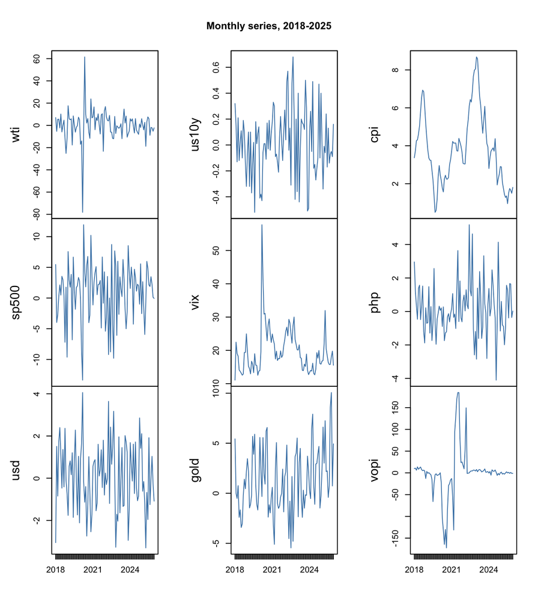

```r
plot(zoo(model_df[c("wti", global_vars, ph_vars)], model_df$month), nc = 3,
     main = "Monthly series, 2018-2025", xlab = "", col = "steelblue")
```

The WTI panel is dominated by the COVID-19 episode: the March 2020 collapse and the May 2020 rebound are far larger than any other month. The same months show the S&P 500 at its worst return, the dollar at its largest gain and the VIX at its peak (57.7). The VIX stays elevated through the rest of 2020, with later spikes in 2022 and April 2025. Three of the five largest monthly increases in the 10-year yield come in 2022, as the Federal Reserve raised rates, and Philippine inflation peaks at 8.7% in Jan 2023. The peso’s two largest monthly depreciations are June and September 2022, when the dollar was also strong. The manufacturing panel shows the 2020 lockdown collapse and the 2021 base-effect rebound described above.

## Initial Regression Model

Our baseline is an ordinary least squares (OLS) regression of the WTI monthly log return on the global financial conditions. We then add the Philippine macro conditions to the same model, so that comparing the two answers the second part of the research question directly. The stress-month question is left for the Advanced Regression section.

The first model uses only the global financial conditions.

```r
m_global <- lm(wti ~ sp500 + usd + us10y + vix + gold, data = model_df)
summary(m_global)
```

```
##
## Call:
## lm(formula = wti ~ sp500 + usd + us10y + vix + gold, data = model_df)
##
## Residuals:
##     Min      1Q  Median      3Q     Max
## -32.879  -6.368  -0.061   4.821  61.013
##
## Coefficients:
##             Estimate Std. Error t value Pr(>|t|)
## (Intercept)   7.3327     3.7579   1.951  0.05413 .
## sp500         0.8899     0.2960   3.006  0.00343 **
## usd          -1.9977     0.9176  -2.177  0.03208 *
## us10y        20.9661     4.6677   4.492 2.09e-05 ***
## vix          -0.4109     0.1738  -2.365  0.02018 *
## gold         -0.2872     0.3786  -0.758  0.45016
## ---
## Signif. codes:  0 '***' 0.001 '**' 0.01 '*' 0.05 '.' 0.1 ' ' 1
##
## Residual standard error: 11.03 on 90 degrees of freedom
## Multiple R-squared:  0.3727, Adjusted R-squared:  0.3378
## F-statistic: 10.69 on 5 and 90 DF,  p-value: 4.383e-08
```

The second adds the three Philippine variables.

```r
m_full <- update(m_global, . ~ . + cpi + php + vopi)
summary(m_full)
```

```
##
## Call:
## lm(formula = wti ~ sp500 + usd + us10y + vix + gold + cpi + php +
##     vopi, data = model_df)
##
## Residuals:
##     Min      1Q  Median      3Q     Max
## -31.206  -5.801   0.191   6.211  55.716
##
## Coefficients:
##             Estimate Std. Error t value Pr(>|t|)
## (Intercept)  9.78764    4.64511   2.107  0.03799 *
## sp500        0.85115    0.29529   2.882  0.00497 **
## usd         -2.82661    0.97994  -2.884  0.00494 **
## us10y       19.27383    4.68022   4.118 8.67e-05 ***
## vix         -0.44731    0.17960  -2.491  0.01465 *
## gold        -0.42197    0.38617  -1.093  0.27753
## cpi         -0.44331    0.62237  -0.712  0.47819
## php          1.76808    0.85373   2.071  0.04132 *
## vopi        -0.02801    0.02191  -1.278  0.20454
## ---
## Signif. codes:  0 '***' 0.001 '**' 0.01 '*' 0.05 '.' 0.1 ' ' 1
##
## Residual standard error: 10.85 on 87 degrees of freedom
## Multiple R-squared:  0.4139, Adjusted R-squared:   0.36
## F-statistic: 7.679 on 8 and 87 DF,  p-value: 9.916e-08
```

In the full model, equity returns, the dollar, Treasury yields and the VIX are all significant at the 5% level. Each coefficient is read ceteris paribus, that is, holding the other regressors constant. On that basis, a 1% rise in the S&P 500 is associated with a 0.85 percentage point higher WTI return, and a 1% rise in the broad dollar with a 2.83 point lower one. Oil moves with risk appetite and against the currency it is priced in. With the other variables fixed, a one point rise in the VIX goes with a 0.45 point lower return. The yield coefficient is large and positive (19.3 points per percentage point of yield change), which reads more naturally as yields and oil both responding to growth news than as yields pushing oil up. Gold is not significant once the other conditions are in. These signs match the expectations in the variable table.

The overall F-test rejects the null that all eight slope coefficients are zero (F = 7.68, p < 0.001), so the regressors jointly explain WTI returns.

### Statistical inference

For each coefficient we test H₀: β = 0 (no association with WTI returns, holding the others constant) against the two-sided H₁: β ≠ 0, at the 5% level. The table below adds the 95% confidence interval for each coefficient, and the change in WTI return implied by a typical (one standard deviation) move in each regressor. That last column measures economic significance. For comparison, the standard deviation of WTI returns is 13.6 percentage points.

```r
cs_full <- coef(summary(m_full))
ci_full <- confint(m_full)
x_vars  <- c(global_vars, ph_vars)
inference <- data.frame(
  term      = x_vars,
  estimate  = cs_full[x_vars, "Estimate"],
  ci_low    = ci_full[x_vars, 1],
  ci_high   = ci_full[x_vars, 2],
  p_value   = cs_full[x_vars, "Pr(>|t|)"],
  sd_x      = sapply(model_df[x_vars], sd),
  row.names = NULL
)
inference$effect_1sd <- inference$estimate * inference$sd_x
knitr::kable(transform(inference, p_value = format.pval(p_value, digits = 2)), digits = 2,
             col.names = c("term", "estimate", "95% CI low", "95% CI high", "p-value",
                           "SD of regressor", "effect of 1 SD move (pp of WTI return)"))
```

| term | estimate | 95% CI low | 95% CI high | p-value | SD of regressor | effect of 1 SD move (pp of WTI return) |
| --- | --- | --- | --- | --- | --- | --- |
| sp500 | 0.85 | 0.26 | 1.44 | 0.0050 | 4.77 | 4.06 |
| usd | -2.83 | -4.77 | -0.88 | 0.0049 | 1.60 | -4.51 |
| us10y | 19.27 | 9.97 | 28.58 | 8.7e-05 | 0.26 | 4.95 |
| vix | -0.45 | -0.80 | -0.09 | 0.0147 | 6.76 | -3.03 |
| gold | -0.42 | -1.19 | 0.35 | 0.2775 | 3.21 | -1.36 |
| cpi | -0.44 | -1.68 | 0.79 | 0.4782 | 1.91 | -0.85 |
| php | 1.77 | 0.07 | 3.46 | 0.0413 | 1.58 | 2.79 |
| vopi | -0.03 | -0.07 | 0.02 | 0.2045 | 55.74 | -1.56 |

The S&P 500, dollar, yield, VIX and peso coefficients reject H₀ at 5%, and their confidence intervals exclude zero. Gold, CPI and manufacturing do not, and their intervals comfortably include zero.

A small p-value says an effect is unlikely to be zero, not that it is large, so we look at both. Here the statistically significant global factors are also economically large: a typical one standard deviation move in the S&P 500, the dollar or Treasury yields shifts the expected WTI return by roughly 4 to 5 percentage points, about a third of WTI’s own monthly standard deviation. But the intervals are wide. The dollar’s interval runs from -4.8 to -0.9, so the data cannot tell a small dollar effect from a large one. The manufacturing coefficient shows the reverse case: it looks tiny (-0.028 per point), but because `vopi` swings so widely its one standard deviation effect is comparable to gold’s, and it is still not statistically different from zero. A coefficient’s size alone therefore says little until it is scaled by how much the regressor actually moves.

### Model comparison: do the Philippine variables add explanatory power?

Whether the Philippine block earns its place is a question about the three coefficients jointly, so we test it with a nested F-test (H₀: the CPI, peso and manufacturing coefficients are all zero) and also compare the information criteria, which penalize the extra parameters.

```r
f_test <- anova(m_global, m_full)
f_test
```

```
## Analysis of Variance Table
##
## Model 1: wti ~ sp500 + usd + us10y + vix + gold
## Model 2: wti ~ sp500 + usd + us10y + vix + gold + cpi + php + vopi
##   Res.Df   RSS Df Sum of Sq      F Pr(>F)
## 1     90 10958
## 2     87 10239  3     719.4 2.0376 0.1145
```

```r
models <- list("Global only" = m_global, "Global + Philippine" = m_full)
knitr::kable(data.frame(
  model  = names(models),
  k      = sapply(models, function(m) length(coef(m)) - 1),
  R2     = sapply(models, function(m) summary(m)$r.squared),
  adj_R2 = sapply(models, function(m) summary(m)$adj.r.squared),
  AIC    = sapply(models, AIC),
  BIC    = sapply(models, BIC),
  row.names = NULL
), digits = 3)
```

| model | k | R2 | adj_R2 | AIC | BIC |
| --- | --- | --- | --- | --- | --- |
| Global only | 5 | 0.373 | 0.338 | 741.234 | 759.185 |
| Global + Philippine | 8 | 0.414 | 0.360 | 740.716 | 766.359 |

The global model explains 37.3% of the variation in WTI returns (33.8% adjusted). Adding the Philippine block raises R-squared to 41.4% but adjusted R-squared only to 36%, the three new terms are not jointly significant (F-test p-value 0.114), and BIC prefers the global model while AIC is essentially a tie. Only the peso term is individually significant, and its sign should not be read as the peso driving oil. The causal direction more plausibly runs the other way, since the Philippines is a net oil importer and a higher oil price weakens the peso, and the peso is also correlated with the dollar and risk sentiment. So at this stage there is little evidence that Philippine macro conditions add explanatory power beyond the global ones.

These are associations in a single sample, and the standard errors behind the stars assume the usual OLS conditions hold. The next section checks that.

## Diagnostics

We run the diagnostics on the full model (`m_full`), since the global model is nested inside it and any problem in the shared terms will show up in both. All tests use a 5% level and, except where stated, have the assumption holding as the null hypothesis, so a small p-value signals a problem.

### Multicollinearity

The Philippine peso moves with the dollar and with global risk sentiment, so we check the variance inflation factors (VIF) first. As a rule of thumb, values above 5 to 10 are worrying.

```r
X   <- model_df[c(global_vars, ph_vars)]
vif <- sapply(names(X), function(v)
  1 / (1 - summary(lm(reformulate(setdiff(names(X), v), v), data = X))$r.squared))
round(vif, 2)
```

```
## sp500   usd us10y   vix  gold   cpi   php  vopi
##  1.60  1.98  1.17  1.19  1.24  1.14  1.47  1.20
```

The largest VIF is 1.98 (usd), so multicollinearity is not a concern even between the dollar index and the peso.

### Residual plots

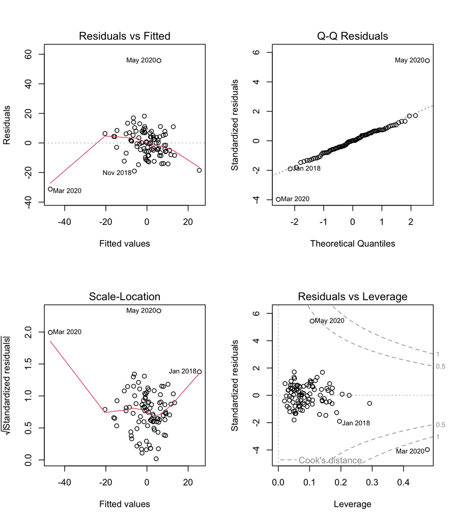

```r
par(mfrow = c(2, 2))
plot(m_full, which = c(1, 2, 3, 5), id.n = 3)   # points are labelled by month
```

```r
par(mfrow = c(1, 1))
```

Most of the points look reasonable, but two do not. In the residuals versus fitted panel (top left) the smoother bends at both ends, where only a few points sit, and March 2020 (fitted far below the rest) and May 2020 (a residual above 50) stand apart. The Q-Q plot (top right) shows the bulk of the residuals tracking the line while those same two months sit far off it at opposite ends. In the scale-location panel (bottom left) the smoother turns up on the left because of March 2020, and in the last panel (bottom right) March 2020 has by far the highest leverage and lies beyond the Cook’s distance contour of 1.

### Formal tests

```r
diag_battery <- function(m) {
  aux <- data.frame(fit = fitted(m))
  tests <- list(
    "Functional form"    = list("RESET (fitted^2, fitted^3)" = resettest(m, power = 2:3, type = "fitted")),
    "Normality"          = list("Shapiro-Wilk"   = shapiro.test(resid(m)),
                                "Jarque-Bera"    = jarque.bera.test(resid(m))),
    "Homoskedasticity"   = list("Breusch-Pagan (regressors)"    = bptest(m),
                                "Breusch-Pagan (fitted values)" = bptest(m, ~ fit + I(fit^2), data = aux)),
    "No autocorrelation" = list("Durbin-Watson (lag 1)"     = dwtest(m),
                                "Breusch-Godfrey (lags 1-3)" = bgtest(m, order = 3),
                                "Ljung-Box (12 lags)"        = Box.test(resid(m), lag = 12, type = "Ljung-Box")))
  do.call(rbind, lapply(names(tests), function(a)
    data.frame(assumption = a,
               test       = names(tests[[a]]),
               statistic  = sapply(tests[[a]], function(t) unname(t$statistic)[1]),
               p_value    = sapply(tests[[a]], function(t) t$p.value),
               row.names  = NULL)))
}

fmt_p <- function(p) ifelse(p < 0.001, "<0.001", sprintf("%.3f", p))

battery <- diag_battery(m_full)
battery$verdict <- ifelse(battery$p_value < 0.05, "violated", "no evidence of violation")
knitr::kable(transform(battery, statistic = round(statistic, 3), p_value = fmt_p(p_value)))
```

| assumption | test | statistic | p_value | verdict |
| --- | --- | --- | --- | --- |
| Functional form | RESET (fitted^2, fitted^3) | 9.320 | <0.001 | violated |
| Normality | Shapiro-Wilk | 0.901 | <0.001 | violated |
| Normality | Jarque-Bera | 256.444 | <0.001 | violated |
| Homoskedasticity | Breusch-Pagan (regressors) | 15.076 | 0.058 | no evidence of violation |
| Homoskedasticity | Breusch-Pagan (fitted values) | 6.976 | 0.031 | violated |
| No autocorrelation | Durbin-Watson (lag 1) | 1.848 | 0.150 | no evidence of violation |
| No autocorrelation | Breusch-Godfrey (lags 1-3) | 5.959 | 0.114 | no evidence of violation |
| No autocorrelation | Ljung-Box (12 lags) | 10.081 | 0.609 | no evidence of violation |

Reading the table against the plots:

- Functional form: RESET rejects (p <0.001), so the linear specification leaves systematic structure in the residuals.
- Normality: Both tests reject decisively. The residual skewness is 1.23 and kurtosis 10.4 against 0 and 3 for a normal. The Q-Q plot shows this comes from a couple of extreme months and not from the bulk of the sample, but with 96 observations the coefficient t-tests are only approximately valid and a few extreme residuals make that approximation worse.
- Homoskedasticity: The evidence is borderline, with the regressor-based Breusch-Pagan test just above 5% (p = 0.058) and the fitted-value version just below (p = 0.031). We treat it as a likely problem and check it again after dealing with the outliers.
- Autocorrelation: None of the three tests rejects, so there is no evidence of serial correlation in the residuals. This is the one assumption that is comfortably satisfied.

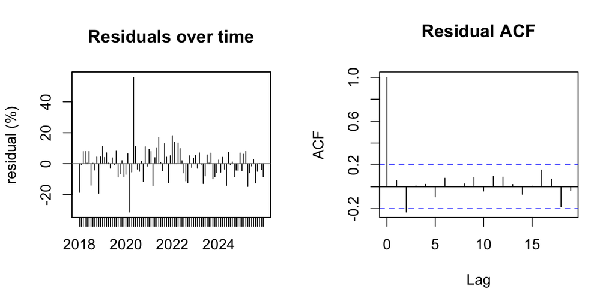

```r
par(mfrow = c(1, 2))
plot(zoo(resid(m_full), model_df$month), type = "h", xlab = "", ylab = "residual (%)",
     main = "Residuals over time")
abline(h = 0, col = "grey50")
acf(resid(m_full), main = "Residual ACF")
```

```r
par(mfrow = c(1, 1))
```

The ACF has a single spike at lag 2 (-0.23) that just crosses the 95% band, which is about what chance alone produces across a dozen lags, and the joint tests above do not reject. The time plot shows where the large residuals are: the two spikes in 2020 stand well clear of the rest of the sample.

### Influential observations

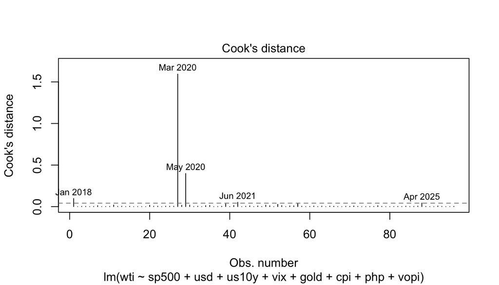

```r
n <- nobs(m_full)
p <- length(coef(m_full))

infl <- data.frame(cooks_d  = cooks.distance(m_full),
                   leverage = hatvalues(m_full),
                   rstudent = rstudent(m_full),
                   wti      = model_df$wti,
                   fitted   = fitted(m_full))

plot(m_full, which = 4, id.n = 5)
abline(h = 4 / n, lty = 2, col = "grey50")
```

```r
knitr::kable(head(infl[order(-infl$cooks_d), ], 5), digits = 2)
```

|  | cooks_d | leverage | rstudent | wti | fitted |
| --- | --- | --- | --- | --- | --- |
| Mar 2020 | 1.59 | 0.48 | -4.37 | -78.20 | -46.99 |
| May 2020 | 0.40 | 0.11 | 6.66 | 61.50 | 5.79 |
| Jan 2018 | 0.10 | 0.20 | -1.93 | 6.96 | 25.45 |
| Jun 2021 | 0.05 | 0.14 | 1.70 | 10.32 | -6.62 |
| Apr 2025 | 0.04 | 0.15 | -1.48 | -18.80 | -4.12 |

Two months stand out. March 2020 has a Cook’s distance of 1.59, many times the usual 4/n cutoff of 0.042 and above 1, which means a single observation is materially moving the whole fit. It is the month of the COVID-19 demand collapse and the OPEC+ price war, with a WTI log return of -78.2% (more than halving the price). It also has the highest leverage (0.48 against a 2p/n cutoff of 0.19), because the S&P 500 was at its lowest return, the VIX at its highest and the dollar at its largest gain of the whole sample in that same month. May 2020 is the opposite case, a rebound of 61.5% that the model badly misses (studentized residual 6.7). These are real market events and not data errors, so they should not be deleted without a reason. But we can ask how much they matter by refitting without them.

```r
covid <- c("Mar 2020", "May 2020")
m_wo  <- update(m_full, data = model_df[!rownames(model_df) %in% covid, ])

cs_all <- coef(summary(m_full))
cs_wo  <- coef(summary(m_wo))
knitr::kable(data.frame(
  term        = rownames(cs_all),
  estimate    = round(cs_all[, "Estimate"], 3),
  p_value     = fmt_p(cs_all[, "Pr(>|t|)"]),
  estimate_wo = round(cs_wo[, "Estimate"], 3),
  p_value_wo  = fmt_p(cs_wo[, "Pr(>|t|)"]),
  row.names   = NULL
), col.names = c("term", "estimate", "p-value", "estimate (excl.)", "p-value (excl.)"))
```

| term | estimate | p-value | estimate (excl.) | p-value (excl.) |
| --- | --- | --- | --- | --- |
| (Intercept) | 9.788 | 0.038 | 4.127 | 0.265 |
| sp500 | 0.851 | 0.005 | 0.652 | 0.003 |
| usd | -2.827 | 0.005 | -1.517 | 0.043 |
| us10y | 19.274 | <0.001 | 13.992 | <0.001 |
| vix | -0.447 | 0.015 | -0.136 | 0.404 |
| gold | -0.422 | 0.278 | -0.417 | 0.142 |
| cpi | -0.443 | 0.478 | -0.513 | 0.267 |
| php | 1.768 | 0.041 | 0.951 | 0.134 |
| vopi | -0.028 | 0.205 | 0.005 | 0.757 |

```r
tests_wo <- diag_battery(m_wo)
knitr::kable(data.frame(
  test              = battery$test,
  `p-value`         = fmt_p(battery$p_value),
  `p-value (excl.)` = fmt_p(tests_wo$p_value),
  check.names = FALSE
))
```

| test | p-value | p-value (excl.) |
| --- | --- | --- |
| RESET (fitted^2, fitted^3) | <0.001 | 0.818 |
| Shapiro-Wilk | <0.001 | 0.730 |
| Jarque-Bera | <0.001 | 0.463 |
| Breusch-Pagan (regressors) | 0.058 | 0.268 |
| Breusch-Pagan (fitted values) | 0.031 | 0.603 |
| Durbin-Watson (lag 1) | 0.150 | 0.337 |
| Breusch-Godfrey (lags 1-3) | 0.114 | 0.245 |
| Ljung-Box (12 lags) | 0.609 | 0.818 |

Removing just these two months changes the picture considerably. Adjusted R-squared drops from 36% to 23.2%, the VIX and peso coefficients lose their significance, the dollar and S&P 500 coefficients shrink (the dollar only just stays significant), and the functional form, normality and heteroskedasticity tests no longer reject. In other words, much of the apparent fit and most of the assumption violations are produced by the two COVID months, while the S&P 500 and Treasury yield effects are robust to their removal. This is a sensitivity check and not our fix, and how to treat these months is a modeling decision for the next section.

### Summary of diagnostics

| Assumption | Result | Comment |
| --- | --- | --- |
| No multicollinearity | holds | all VIFs are small |
| No autocorrelation | holds | DW, Breusch-Godfrey and Ljung-Box all fail to reject |
| Correct functional form | violated | RESET rejects, driven by the 2020 outliers |
| Normal errors | violated | heavy tails, skewness and excess kurtosis from the same months |
| Constant variance | borderline | one of two Breusch-Pagan tests rejects |
| No influential points | violated | March 2020 has a Cook’s distance above 1 |

The OLS baseline therefore has the right signs for the global factors but unreliable standard errors and an inflated fit, because a small number of crisis months dominate the sample. The Model Improvement section addresses this directly.

## Model Improvement

The diagnostics point to two related problems:

1. **Unreliable standard errors.** Heteroskedasticity (error variance that is not constant across months) is borderline, and the residuals are far from normal. Either way, the usual OLS standard errors, and the p-values built on them, cannot be taken at face value.
2. **Two months dominate the fit.** March and May 2020 are the source of the RESET, normality and influence failures, and they carry much of the apparent R-squared.

Multicollinearity and autocorrelation are not problems, so they need no remedy. We address the two problems in turn and keep the original model for comparison.

### Remedy 1: heteroskedasticity-robust standard errors

Robust (heteroskedasticity-consistent, or HC) standard errors estimate each coefficient’s uncertainty without assuming a constant error variance. They leave the coefficients themselves unchanged. We use the HC3 version, which is recommended for small samples because it gives more weight to the residuals of high-leverage observations, exactly the situation March 2020 creates.

```r
rob_full <- coeftest(m_full, vcov = vcovHC(m_full, type = "HC3"))
knitr::kable(data.frame(
  term     = rownames(cs_full),
  estimate = round(cs_full[, "Estimate"], 3),
  se_ols   = round(cs_full[, "Std. Error"], 3),
  p_ols    = fmt_p(cs_full[, "Pr(>|t|)"]),
  se_hc3   = round(rob_full[, "Std. Error"], 3),
  p_hc3    = fmt_p(rob_full[, "Pr(>|t|)"]),
  row.names = NULL
), col.names = c("term", "estimate", "SE (OLS)", "p (OLS)", "SE (HC3)", "p (HC3)"))
```

| term | estimate | SE (OLS) | p (OLS) | SE (HC3) | p (HC3) |
| --- | --- | --- | --- | --- | --- |
| (Intercept) | 9.788 | 4.645 | 0.038 | 8.325 | 0.243 |
| sp500 | 0.851 | 0.295 | 0.005 | 0.273 | 0.002 |
| usd | -2.827 | 0.980 | 0.005 | 1.475 | 0.059 |
| us10y | 19.274 | 4.680 | <0.001 | 6.921 | 0.007 |
| vix | -0.447 | 0.180 | 0.015 | 0.532 | 0.402 |
| gold | -0.422 | 0.386 | 0.278 | 0.295 | 0.156 |
| cpi | -0.443 | 0.622 | 0.478 | 0.599 | 0.461 |
| php | 1.768 | 0.854 | 0.041 | 1.012 | 0.084 |
| vopi | -0.028 | 0.022 | 0.205 | 0.033 | 0.400 |

With robust standard errors, only the S&P 500 (p 0.002) and Treasury yields (p 0.007) remain significant at 5%. The VIX standard error roughly triples and its p-value rises to 0.402. The dollar (p 0.059) and the peso (p 0.084) fall to the 10% level. Their apparent significance in the initial model rested on the few high-leverage COVID months. Robust standard errors correct the inference, but the coefficients are still estimated with those two months pulling on them, so this remedy alone is not enough.

### Remedy 2: respecify the model with event dummies for March and May 2020

Deleting the two months would throw away real data without saying why. Instead we add a dummy variable for each month: a variable equal to 1 in that month and 0 in every other. Each dummy absorbs its month’s return completely, so the slope coefficients are estimated from the other 94 months. The dummy coefficients then report how far each month’s return was from what financial conditions alone would predict.

This is justified by what happened in the oil market itself, not just by the statistics. In March 2020, the OPEC+ talks collapsed on 6 March and Saudi Arabia started a price war just as lockdowns cut oil demand. In May 2020, prices rebounded as OPEC+’s record production cut took effect and economies began to reopen. These were supply decisions and physical demand shocks specific to oil, which equity returns, the dollar, yields and the VIX are not designed to capture.

```r
model_df$d_mar20 <- as.numeric(rownames(model_df) == "Mar 2020")
model_df$d_may20 <- as.numeric(rownames(model_df) == "May 2020")

m_full_d   <- update(m_full,   . ~ . + d_mar20 + d_may20, data = model_df)
m_global_d <- update(m_global, . ~ . + d_mar20 + d_may20, data = model_df)
summary(m_full_d)
```

```
##
## Call:
## lm(formula = wti ~ sp500 + usd + us10y + vix + gold + cpi + php +
##     vopi + d_mar20 + d_may20, data = model_df)
##
## Residuals:
##      Min       1Q   Median       3Q      Max
## -20.9333  -4.1142   0.2846   5.6021  17.2762
##
## Coefficients:
##               Estimate Std. Error t value Pr(>|t|)
## (Intercept)   4.126964   3.677845   1.122 0.264973
## sp500         0.651972   0.216668   3.009 0.003448 **
## usd          -1.516701   0.739666  -2.051 0.043394 *
## us10y        13.992058   3.574948   3.914 0.000183 ***
## vix          -0.135917   0.161971  -0.839 0.403741
## gold         -0.417286   0.281814  -1.481 0.142380
## cpi          -0.512903   0.459470  -1.116 0.267443
## php           0.950769   0.629123   1.511 0.134431
## vopi          0.005086   0.016399   0.310 0.757230
## d_mar20     -52.698974  10.967718  -4.805  6.6e-06 ***
## d_may20      58.861499   8.406373   7.002  5.5e-10 ***
## ---
## Signif. codes:  0 '***' 0.001 '**' 0.01 '*' 0.05 '.' 0.1 ' ' 1
##
## Residual standard error: 7.907 on 85 degrees of freedom
## Multiple R-squared:  0.6958, Adjusted R-squared:   0.66
## F-statistic: 19.44 on 10 and 85 DF,  p-value: < 2.2e-16
```

The March 2020 dummy is -52.7 and the May 2020 dummy is 58.9: even after accounting for the collapse in equities and the spike in the VIX, WTI fell about 50 percentage points more than the financial conditions predict in March, and rose about 60 points more in May.

We repeat the test of the Philippine block in the respecified model.

```r
f_test_d <- anova(m_global_d, m_full_d)
f_test_d
```

```
## Analysis of Variance Table
##
## Model 1: wti ~ sp500 + usd + us10y + vix + gold + d_mar20 + d_may20
## Model 2: wti ~ sp500 + usd + us10y + vix + gold + cpi + php + vopi + d_mar20 +
##     d_may20
##   Res.Df    RSS Df Sum of Sq      F Pr(>F)
## 1     88 5559.4
## 2     85 5314.6  3    244.84 1.3053  0.278
```

The Philippine variables remain jointly insignificant (p 0.278), and the peso coefficient is no longer significant on its own either (p 0.134). We therefore drop them and take the global model with the two event dummies (`m_global_d`) as the improved model. It also has the lowest AIC and BIC of the four specifications (see the comparison below). The choice does not rest on significance alone. It also rests on the diagnostics, the information criteria and the economic argument that the Philippines is a price taker in oil.

### Diagnostics on the improved model

```r
battery_d <- diag_battery(m_global_d)
knitr::kable(data.frame(
  assumption = battery$assumption,
  test       = battery$test,
  `p-value (initial, m_full)`       = fmt_p(battery$p_value),
  `p-value (improved, m_global_d)`  = fmt_p(battery_d$p_value),
  check.names = FALSE
))
```

| assumption | test | p-value (initial, m_full) | p-value (improved, m_global_d) |
| --- | --- | --- | --- |
| Functional form | RESET (fitted^2, fitted^3) | <0.001 | 0.872 |
| Normality | Shapiro-Wilk | <0.001 | 0.778 |
| Normality | Jarque-Bera | <0.001 | 0.358 |
| Homoskedasticity | Breusch-Pagan (regressors) | 0.058 | 0.397 |
| Homoskedasticity | Breusch-Pagan (fitted values) | 0.031 | 0.601 |
| No autocorrelation | Durbin-Watson (lag 1) | 0.150 | 0.292 |
| No autocorrelation | Breusch-Godfrey (lags 1-3) | 0.114 | 0.086 |
| No autocorrelation | Ljung-Box (12 lags) | 0.609 | 0.828 |

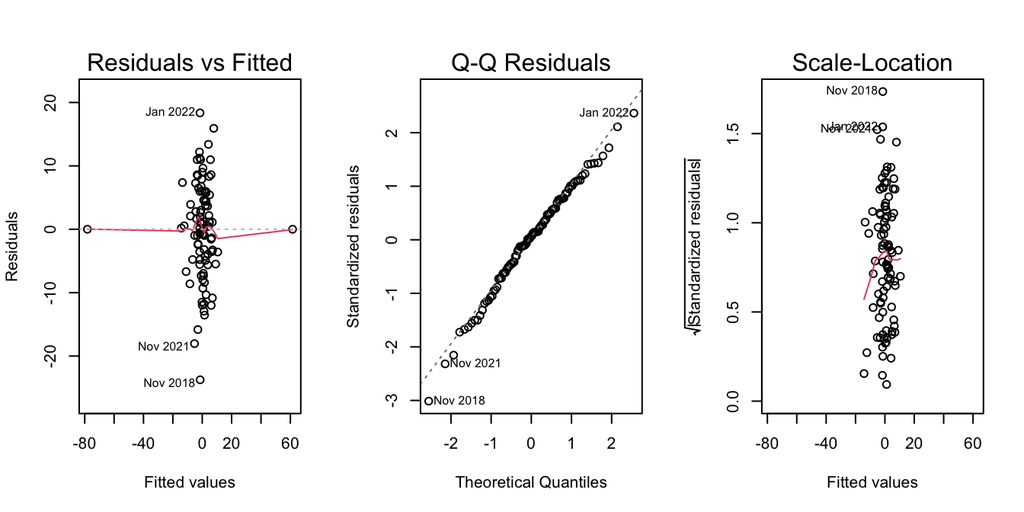

```r
par(mfrow = c(1, 3))
plot(m_global_d, which = 1:3, id.n = 3)
```

```r
par(mfrow = c(1, 1))

cd_d <- cooks.distance(m_global_d)
cd_d <- cd_d[is.finite(cd_d)]          # the two dummied months have no Cook's distance
round(head(sort(cd_d, decreasing = TRUE), 3), 3)
```

```
## Apr 2025 Apr 2020 Nov 2020
##    0.099    0.092    0.060
```

Every assumption that failed now holds: RESET (p 0.872), both normality tests (p 0.778 and 0.358) and both Breusch-Pagan tests (p 0.397 and 0.601) no longer reject, and the autocorrelation tests still do not. The residual plots show no pattern, and the Q-Q plot follows the line. No remaining month is close to the Cook’s distance of 1. The largest is Apr 2025 at 0.1, the month of the U.S. tariff announcements, above the 4/n rule of thumb but nowhere near the influence March 2020 had.

Since the Breusch-Pagan tests no longer reject, the ordinary standard errors are now reasonable. As a check we also compute robust (HC1) standard errors for the slopes. HC3 cannot be used here, because each dummied month has a leverage of exactly 1, and robust standard errors on the dummies themselves are not meaningful for the same reason.

### Comparison of the initial and improved models

```r
rob_d     <- coeftest(m_global_d, vcov = vcovHC(m_global_d, type = "HC1"))
cs_d      <- coef(summary(m_global_d))
all_terms <- union(rownames(cs_full), rownames(cs_d))
pick      <- function(ct, col) ct[match(all_terms, rownames(ct)), col]
slope_only <- !all_terms %in% c("d_mar20", "d_may20")
options(knitr.kable.NA = "")             # blank cells for terms not in a model

knitr::kable(data.frame(
  term       = all_terms,
  est_init   = round(pick(cs_full, "Estimate"), 3),
  p_init     = fmt_p(pick(cs_full, "Pr(>|t|)")),
  p_init_hc3 = fmt_p(pick(rob_full, "Pr(>|t|)")),
  est_impr   = round(pick(cs_d, "Estimate"), 3),
  p_impr     = fmt_p(pick(cs_d, "Pr(>|t|)")),
  p_impr_hc1 = ifelse(slope_only, fmt_p(pick(rob_d, "Pr(>|t|)")), NA),
  row.names  = NULL
), col.names = c("term", "estimate (initial)", "p (initial, OLS)", "p (initial, HC3)",
                 "estimate (improved)", "p (improved, OLS)", "p (improved, HC1)"))
```

| term | estimate (initial) | p (initial, OLS) | p (initial, HC3) | estimate (improved) | p (improved, OLS) | p (improved, HC1) |
| --- | --- | --- | --- | --- | --- | --- |
| (Intercept) | 9.788 | 0.038 | 0.243 | 2.892 | 0.367 | 0.325 |
| sp500 | 0.851 | 0.005 | 0.002 | 0.647 | 0.003 | 0.002 |
| usd | -2.827 | 0.005 | 0.059 | -1.037 | 0.132 | 0.116 |
| us10y | 19.274 | <0.001 | 0.007 | 14.573 | <0.001 | <0.001 |
| vix | -0.447 | 0.015 | 0.402 | -0.174 | 0.269 | 0.264 |
| gold | -0.422 | 0.278 | 0.156 | -0.327 | 0.233 | 0.179 |
| cpi | -0.443 | 0.478 | 0.461 |  |  |  |
| php | 1.768 | 0.041 | 0.084 |  |  |  |
| vopi | -0.028 | 0.205 | 0.400 |  |  |  |
| d_mar20 |  |  |  | -52.037 | <0.001 |  |
| d_may20 |  |  |  | 60.441 | <0.001 |  |

```r
all_models <- list("Initial: global"              = m_global,
                   "Initial: global + Philippine" = m_full,
                   "Improved: global + Philippine + dummies" = m_full_d,
                   "Improved: global + dummies"   = m_global_d)
knitr::kable(data.frame(
  model    = names(all_models),
  k        = sapply(all_models, function(m) length(coef(m)) - 1),
  adj_R2   = sapply(all_models, function(m) summary(m)$adj.r.squared),
  resid_SE = sapply(all_models, sigma),
  AIC      = sapply(all_models, AIC),
  BIC      = sapply(all_models, BIC),
  row.names = NULL
), digits = 3)
```

| model | k | adj_R2 | resid_SE | AIC | BIC |
| --- | --- | --- | --- | --- | --- |
| Initial: global | 5 | 0.338 | 11.034 | 741.234 | 759.185 |
| Initial: global + Philippine | 8 | 0.360 | 10.848 | 740.716 | 766.359 |
| Improved: global + Philippine + dummies | 10 | 0.660 | 7.907 | 681.767 | 712.539 |
| Improved: global + dummies | 7 | 0.656 | 7.948 | 680.091 | 703.170 |

```r
m_global_wo <- update(m_global, data = model_df[!rownames(model_df) %in% covid, ])
```

The adjusted R-squared of the improved model (65.6%) should not be read as a better explanation of oil returns. The dummies fit their two months perfectly, and those months contain much of WTI’s total variation, so the R-squared jumps for a purely mechanical reason. A fairer measure of fit in ordinary months is the global model estimated without March and May 2020, whose adjusted R-squared is 22.4%. Our choice of the improved model rests instead on the diagnostics, the F-test on the Philippine block and the information criteria.

The comparison has four implications:

- Two relationships survive every check: Holding the other conditions constant, a 1% S&P 500 return goes with a 0.65 point higher WTI return (initially 0.85), and a 1 percentage point rise in the 10-year yield with a 14.6 point higher return (initially 19.3). Both are significant with ordinary and robust standard errors and are smaller than in the initial model, which had been inflated by the COVID months.
- The dollar and VIX effects are fragile: Both keep the expected negative sign, but they shrink (dollar -1.04, VIX -0.17) and are not significant (p 0.132 and 0.269). Their significance in the initial model came almost entirely from March and May 2020.
- Philippine conditions add nothing once the global conditions are known: This answers the second part of the research question.
- Most monthly oil-price variation is oil-specific: In ordinary months, financial conditions explain only about a fifth of WTI returns, and in the two COVID months the gap between actual and predicted returns was 50 to 60 percentage points. Supply decisions and physical demand shocks, which these regressors do not measure, drive most of the rest.

The dummies also have a cost for the next step: the model now says nothing about March and May 2020 themselves. Any test of whether the relationships change in stress months in the Advanced Regression section therefore has to rely on the other high-VIX months, and should check that its result is not just a restatement of these two.

### Robustness check: robust regression without dummies

A reader can fairly ask whether our result depends on choosing the two event dummies after seeing the data. As a check, we fit a robust regression, which down-weights extreme months automatically and uses no dummies.

```r
m_rob <- MASS::rlm(wti ~ sp500 + usd + us10y + vix + gold,
                   data = model_df, psi = MASS::psi.bisquare, maxit = 50)
round(coef(summary(m_rob)), 2)
```

```
##             Value Std. Error t value
## (Intercept)  3.04       2.78    1.09
## sp500        0.63       0.22    2.88
## usd         -0.90       0.68   -1.33
## us10y       13.92       3.45    4.03
## vix         -0.17       0.13   -1.32
## gold        -0.30       0.28   -1.08
```

The robust regression gives an S&P 500 coefficient of 0.63 (t = 2.9) and a yield coefficient of 13.9 (t = 4). The dollar has a t-value of -1.3 and the VIX has -1.3.

### What the diagnostics cannot tell us

The diagnostic tests help us assess the behavior of the regression errors, but they do not address every limitation of the model. First, these tests check how the errors behave, not whether the regressors are exogenous. Oil and the S&P 500 respond to the same shocks, so reverse causality cannot be ruled out, and our results stay associations. Second, we chose the March and May 2020 dummies after seeing the residuals. The oil market events justify them, but the choice was informed by the data. Third, the dummies force two residuals to exactly zero, so part of the clean result in the improved model is mechanical. The robust regression above is our check that the main findings do not depend on this.

## Advanced Regression

The last part of the research question asks whether the relationships change in market-stress months. We test this with interaction terms. A stress dummy equals 1 in months when the VIX is in its top quartile and 0 otherwise. Interacting the dummy with each regressor lets the slopes differ in stress months. The VIX level enters on its own, because the stress dummy is built from it.

March and May 2020 stay dummied, as in the improved model. This keeps the two extreme months from deciding the result. The stress months we test are the other high-VIX months.

```r
vix_cut <- quantile(model_df$vix, 0.75)
model_df$stress <- as.numeric(model_df$vix > vix_cut)
covid_dummied <- model_df$d_mar20 == 1 | model_df$d_may20 == 1
n_stress <- sum(model_df$stress == 1 & !covid_dummied)
c(vix_cutoff = round(unname(vix_cut), 1), stress_months_excl_dummied = n_stress)
```

```
##                 vix_cutoff stress_months_excl_dummied
##                       22.4                       22.0
```

The cutoff is a VIX of 22.4. It leaves 22 stress months besides March and May 2020. This is a small group, so the tests have limited power.

```r
m_stress <- lm(wti ~ sp500 + usd + us10y + gold + vix + stress +
                 sp500:stress + usd:stress + us10y:stress + gold:stress +
                 d_mar20 + d_may20, data = model_df)
m_base <- update(m_global_d, data = model_df)
summary(m_stress)
```

```
##
## Call:
## lm(formula = wti ~ sp500 + usd + us10y + gold + vix + stress +
##     sp500:stress + usd:stress + us10y:stress + gold:stress +
##     d_mar20 + d_may20, data = model_df)
##
## Residuals:
##      Min       1Q   Median       3Q      Max
## -22.2913  -4.1224   0.0904   5.2763  15.8616
##
## Coefficients:
##               Estimate Std. Error t value Pr(>|t|)
## (Intercept)    7.90633    4.85632   1.628  0.10731
## sp500          0.61245    0.31445   1.948  0.05483 .
## usd           -0.98228    0.80340  -1.223  0.22492
## us10y         13.45312    4.07434   3.302  0.00142 **
## gold          -0.08526    0.33022  -0.258  0.79690
## vix           -0.51772    0.27339  -1.894  0.06175 .
## stress         5.53794    3.51168   1.577  0.11860
## d_mar20      -36.95353   14.99029  -2.465  0.01576 *
## d_may20       60.25375    8.27349   7.283 1.71e-10 ***
## sp500:stress   0.12516    0.45987   0.272  0.78617
## usd:stress    -0.69224    1.83072  -0.378  0.70630
## us10y:stress   6.07581    9.45520   0.643  0.52226
## gold:stress   -0.70846    0.65448  -1.082  0.28217
## ---
## Signif. codes:  0 '***' 0.001 '**' 0.01 '*' 0.05 '.' 0.1 ' ' 1
##
## Residual standard error: 7.966 on 83 degrees of freedom
## Multiple R-squared:  0.6985, Adjusted R-squared:  0.6549
## F-statistic: 16.02 on 12 and 83 DF,  p-value: < 2.2e-16
```

First we test all four interactions together. The null is that the slopes are the same in stress and calm months.

```r
# base model plus only the stress intercept, so the F-test isolates the 4 interactions
m_stress0 <- update(m_base, . ~ . + stress)
f_stress <- anova(m_stress0, m_stress)
f_stress
```

```
## Analysis of Variance Table
##
## Model 1: wti ~ sp500 + usd + us10y + vix + gold + d_mar20 + d_may20 +
##     stress
## Model 2: wti ~ sp500 + usd + us10y + gold + vix + stress + sp500:stress +
##     usd:stress + us10y:stress + gold:stress + d_mar20 + d_may20
##   Res.Df    RSS Df Sum of Sq     F Pr(>F)
## 1     87 5374.4
## 2     83 5267.2  4    107.12 0.422 0.7923
```

```r
p_stress <- f_stress$"Pr(>F)"[2]

# same test with robust standard errors
w_stress <- waldtest(m_stress0, m_stress, vcov = function(x) vcovHC(x, type = "HC1"))
w_stress
```

```
## Wald test
##
## Model 1: wti ~ sp500 + usd + us10y + vix + gold + d_mar20 + d_may20 +
##     stress
## Model 2: wti ~ sp500 + usd + us10y + gold + vix + stress + sp500:stress +
##     usd:stress + us10y:stress + gold:stress + d_mar20 + d_may20
##   Res.Df Df     F Pr(>F)
## 1     87
## 2     83  4 0.382 0.8209
```

```r
p_stress_rob <- w_stress$"Pr(>F)"[2]
```

The joint F-test does not reject the null of equal slopes (p 0.792). With HC1 standard errors the same test gives p 0.821.

Next we check each interaction with robust standard errors. The dummied months have leverage of 1, so we use HC1, as in the improved model.

```r
rob_stress <- coeftest(m_stress, vcov = vcovHC(m_stress, type = "HC1"))
int_terms <- c("sp500:stress", "usd:stress", "us10y:stress", "gold:stress")
knitr::kable(data.frame(
  term = int_terms,
  estimate = round(coef(m_stress)[int_terms], 3),
  se_hc1 = round(rob_stress[int_terms, "Std. Error"], 3),
  p_hc1 = fmt_p(rob_stress[int_terms, "Pr(>|t|)"]),
  row.names = NULL
), col.names = c("interaction", "estimate", "SE (HC1)", "p (HC1)"))
```

| interaction | estimate | SE (HC1) | p (HC1) |
| --- | --- | --- | --- |
| sp500:stress | 0.125 | 0.477 | 0.794 |
| usd:stress | -0.692 | 2.103 | 0.743 |
| us10y:stress | 6.076 | 10.561 | 0.567 |
| gold:stress | -0.708 | 0.640 | 0.271 |

The slope in stress months is the base slope plus the interaction. For the S&P 500, the calm-month slope is 0.61 and the stress-month slope is 0.74. For the 10-year yield, the calm-month slope is 13.5 and the stress-month slope is 19.5.

Diagnostics on the stress model:

```r
battery_s <- diag_battery(m_stress)
knitr::kable(data.frame(
  test = battery_s$test,
  `p-value` = fmt_p(battery_s$p_value),
  check.names = FALSE
))
```

| test | p-value |
| --- | --- |
| RESET (fitted^2, fitted^3) | 0.911 |
| Shapiro-Wilk | 0.558 |
| Jarque-Bera | 0.342 |
| Breusch-Pagan (regressors) | 0.260 |
| Breusch-Pagan (fitted values) | 0.531 |
| Durbin-Watson (lag 1) | 0.244 |
| Breusch-Godfrey (lags 1-3) | 0.174 |
| Ljung-Box (12 lags) | 0.963 |

Reading the results:

- Joint test: There is no evidence that the slopes differ between stress and calm months.
- Individual terms: No interaction is significant with HC1 standard errors. The smallest p-value is 0.271. The S&P 500 interaction is 0.13 and the 10-year yield interaction is 6.1. Both are positive, but both are small next to their standard errors.
- Diagnostics: The functional form, normality and variance tests do not reject, so the ordinary standard errors are reasonable.
- Limits: The stress group is small. A non-rejection here does not prove the relationships are stable. It says the data cannot detect a change.

## Financial Interpretation

In this section we read our improved model, `m_global_d`. It holds the five global conditions and the March and May 2020 dummies. We read all coefficients as associations in one sample, not causal effects.

Equity returns. Oil moves with risk appetite. A 1% S&P 500 return goes with a 0.65 point higher WTI return. A one standard deviation move in the index (4.8 points) shifts the expected WTI return by 3.1 points. The link survives robust standard errors. Strong equity months signal stronger growth and stronger oil demand.

Treasury yields. A 1 percentage point rise in the 10-year yield goes with a 14.6 point higher WTI return. This does not mean higher borrowing costs lift oil. Growth news probably moves both. Yields work here as a growth signal.

The dollar. The sign is negative, as expected. Oil is priced in dollars, so a stronger dollar makes it dearer for other buyers. The coefficient is -1.04 and is not significant (p 0.132). We cannot tell a small dollar effect from zero with this data. The dollar looked strong in the initial model only because of March and May 2020.

The VIX. The sign is negative, as expected. Higher uncertainty goes with risk-off selling. The coefficient is -0.17 and is not significant (p 0.269). Its earlier significance also came from the two COVID months.

Gold. Gold is not significant. One reason is timing. Gold enters as a return on monthly average prices, while WTI uses month-end prices. This weakens any same-month link.

Philippine conditions. CPI inflation, the peso and manufacturing output are not jointly significant. The Philippines is a price taker in oil. Any link runs from oil to local prices and the peso, not the other way. The peso looked significant in the initial model, but that result more plausibly reflects the reverse direction and its link to the dollar. For Philippine firms and policymakers, oil is an external shock. Local conditions do not help explain it.

For Philippine importers and fuel-cost planners, the practical reading is that local indicators will not warn them about oil. CPI, the peso and manufacturing output add no explanatory power, so oil should be treated as an external shock. The signals worth watching are global, mainly the S&P 500 and Treasury yields. If the exposure needs managing, the better tool is an oil-linked hedging instrument, not a view on the peso or local inflation.

Event months. The March 2020 dummy is -52 and the May 2020 dummy is 60.4 in the improved model. Even after accounting for equities, the dollar, yields and the VIX, oil moved far more than financial conditions predict in those months. The causes were oil-specific. They were the OPEC+ breakdown and price war in March, and the record production cut in May.

Fit. In ordinary months, the global model explains 22.4% of WTI return variation (adjusted). Financial conditions are a weak guide to monthly oil returns. Supply decisions and physical demand shocks drive most of the rest.

Scenarios. The table below turns the coefficients into typical WTI moves.

```r
b <- coef(m_global_d)
scen <- data.frame(
  scenario = c("S&P 500 falls 10%", "S&P 500 rises 10%",
               "10-year yield rises 0.5 pp", "10-year yield falls 0.5 pp"),
  wti_return_pp = unname(c(-10 * b["sp500"], 10 * b["sp500"],
                           0.5 * b["us10y"], -0.5 * b["us10y"]))
)
knitr::kable(scen, digits = 1, col.names = c("Scenario", "Associated WTI return (pp)"))
```

| Scenario | Associated WTI return (pp) |
| --- | --- |
| S&P 500 falls 10% | -6.5 |
| S&P 500 rises 10% | 6.5 |
| 10-year yield rises 0.5 pp | 7.3 |
| 10-year yield falls 0.5 pp | -7.3 |

With an ordinary-month adjusted R-squared of only 22.4%, actual outcomes can land far from these numbers. Read them as typical co-movement, not a forecast.

Reliability. Our initial standard errors were unreliable because two months dominated the fit. Our improved model passes the diagnostics. It still rests on 96 observations. It also says nothing about March and May 2020, since the dummies absorb them.

Stress months. The stress-month model adds interactions for the S&P 500, dollar, yield and gold. The joint test finds no evidence that the slopes change in the top-quartile VIX months (p 0.792). Only 22 stress months remain after the two COVID dummies, so the test has limited power. For an investor, we read this as follows: the S&P 500 and yield links we found in the full sample are a fair guide in high-VIX months too, but the data cannot rule out a change.

## Recommendation and Conclusion

Recommendations

1. We recommend using the S&P 500 and the 10-year yield as the main financial co-movement signals for oil. They are the only two global conditions that stay significant under every check.
2. We recommend not relying on the dollar or the VIX to explain monthly oil returns. Their effects are not distinguishable from zero outside March and May 2020.
3. We recommend not adding Philippine CPI, the peso or manufacturing output to an oil return model. They add no explanatory power. Treat oil as an external shock to Philippine inflation and the peso.
4. We recommend modeling event months separately, with event dummies and robust standard errors. We do not delete the months, since they are real market events.
5. We recommend not using this model alone to forecast oil. It explains about 22.4% of ordinary-month variation. In future work, we would add oil-specific variables such as inventories and OPEC+ output decisions.
6. We recommend that Philippine firms exposed to fuel costs track global signals and manage the exposure with oil-linked instruments, not with peso or CPI indicators.

Conclusion

Our findings answer the research question in three parts. First, the S&P 500 and the 10-year yield are the global conditions associated with WTI returns. The dollar and the VIX are not robust. Second, Philippine macro conditions add no explanatory power beyond global ones. Third, the joint test of equal slopes in stress and calm months does not reject (p 0.792).

Our initial OLS model overstated both fit and significance. Two COVID months drove its results. Event dummies and robust standard errors give us a model that passes every diagnostic. The limits are clear. The sample has 96 months. The results are associations. Most oil price variation comes from factors outside the model.

Overall, the S&P 500 and the 10-year Treasury yield are the only global conditions with a stable link to WTI monthly returns. The dollar and the VIX lose significance once March and May 2020 are modeled separately. Philippine inflation, the peso and manufacturing output add nothing. We find no evidence that the slopes change in high-VIX months, but only 22 stress months remain, so that test is weak. Financial conditions explain about a fifth of ordinary-month oil returns, so they work as a co-movement signal and not as a forecasting tool. Oil-specific supply and demand shocks drive the rest. All results are associations, not causal effects.

## References

Data sources

Bangko Sentral ng Pilipinas. Peso per US dollar exchange rate, monthly. Downloaded file bsp_pesodollar.xlsx.

Federal Reserve Bank of St. Louis. FRED Economic Data. Series DCOILWTICO (WTI spot price), DTWEXBGS (broad US dollar index), VIXCLS (CBOE Volatility Index) and DGS10 (10-year Treasury yield). https://fred.stlouisfed.org.

Philippine Statistics Authority. Consumer Price Index and Manufacturing Volume of Production Index (MISSI). Downloaded files in data/raw.

World Gold Council. Gold price monthly averages. Downloaded file wgc_gold_price_averages.xlsx.

Yahoo Finance. S&P 500 index (^GSPC), accessed through the quantmod package.

Oil market events

Bloomberg News. OPEC+ Talks Collapse, Threatening Russia-Saudi Oil Alliance. 6 March 2020. Published by Transport Topics. https://www.ttnews.com/articles/opec-talks-collapse-threatening-russia-saudi-oil-alliance

CRISIL Research. Oil’s not well. 18 March 2020. https://www.crisil.com/en/home/our-analysis/views-and-commentaries/2020/03/oils-not-well.html

Hydrocarbon Engineering. OPEC+ agrees massive deal to cut oil output. 14 April 2020. https://www.hydrocarbonengineering.com/refining/14042020/opec-agrees-massive-deal-to-cut-oil-output/ (quotes the OPEC ministerial meeting statement of 12 April 2020).

Gambrell, J., Associated Press. Global pact forged to contain oil price crash. 12 April 2020. https://www.wgbh.org/news/international-news/2020-04-12/global-pact-forged-to-contain-oil-price-crash

Akram, Q. F. (2009). Commodity prices, interest rates and the dollar. Energy Economics, 31(6), 838-851.

Basher, S. A., Haug, A. A., and Sadorsky, P. (2012). Oil prices, exchange rates and emerging stock markets. Energy Economics, 34(1), 227-240.

Chen, N.-F., Roll, R., and Ross, S. A. (1986). Economic forces and the stock market. Journal of Business, 59(3), 383-403.

Kilian, L. (2009). Not all oil price shocks are alike: Disentangling demand and supply shocks in the crude oil market. American Economic Review, 99(3), 1053-1069.

Kilian, L., and Park, C. (2009). The impact of oil price shocks on the U.S. stock market. International Economic Review, 50(4), 1267-1287.

Methods and software

Breusch, T. S., and Pagan, A. R. (1979). A simple test for heteroscedasticity and random coefficient variation. Econometrica, 47(5), 1287-1294.

MacKinnon, J. G., and White, H. (1985). Some heteroskedasticity-consistent covariance matrix estimators with improved finite sample properties. Journal of Econometrics, 29(3), 305-325.

Ramsey, J. B. (1969). Tests for specification errors in classical linear least-squares regression analysis. Journal of the Royal Statistical Society, Series B, 31(2), 350-371.

Zeileis, A. (2004). Econometric computing with HC and HAC covariance matrix estimators. Journal of Statistical Software, 11(10), 1-17.

Zeileis, A., and Hothorn, T. (2002). Diagnostic checking in regression relationships. R News, 2(3), 7-10.

R Core Team. R: A language and environment for statistical computing. R Foundation for Statistical Computing, Vienna. Packages used: quantmod, readxl, lmtest, sandwich, tseries.